# Practical Machine Learning Course Project

Romi

10/16/2020

# Intoduction

In recent years using devices such as Jawbone Up, Nike FuelBand, and Fitbit has become more popular, and has made possible to collect more data. This data teaches us about the frequency of the movement one does. In this perticular project, our goal is to analyze the data from the accelerometers in belt, forearm, arm and dumbell form from 6 different participants. These participants will do the barbell lift exercise in 5 different ways. Out outcome will the the “classe” variable which will predict the manner in which they did the exercise.

# Getting, Cleaning and Exploring the Data

## Preparing Environment

Before we start, its good practice to load all the libraries that will be necessary for the project. We also want to set the seed so we get a reproducible report.

```r
library(knitr)
library(caret)
```

```r
library(rpart)
library(rpart.plot)
library(rattle)
library(randomForest)
library(corrplot)
set.seed(1221)
```

## Loading the Data

First we need to load the training and testing data and look at their dimensions. Because the data is already split into two different files, we will not need to split in into training and testing sets.

```r
training <- read.csv("pml-training.csv")
testing <- read.csv("pml-testing.csv")
dim(training)
```

```
## [1] 19622   160
```

```r
dim(testing)
```

```
## [1]  20 160
```

## Cleaining the Data

After looking at the data we notice that there are a lot of NA’s that need to be removed.

```r
training_data <- training[, colSums(is.na(training))==0]
testing_data <- testing[, colSums(is.na(testing))==0]
dim(training_data)
```

```
## [1] 19622    93
```

```r
dim(testing_data)
```

```
## [1] 20 60
```

Now we will remove the first 7 columns that don’t help us much.

```r
training_data <- training_data[, -(1:7)]
testing_data <- testing_data[, -(1:7)]
dim(training_data)
```

```
## [1] 19622    86
```

```r
dim(testing_data)
```

```
## [1] 20 53
```

Because we want to get the highest accuracy possible, we will want to split the training data into training and testing sets. This will allow us to test the models before the actual testing, and therefore receive the accuracy and choose the best model.

```r
inTrain <- createDataPartition(training_data$classe, p = 0.7, list = FALSE)
trainSet <- training_data[inTrain, ]
testSet <- training_data[-inTrain, ]
dim(trainSet)
```

```
## [1] 13737    86
```

```r
dim(testSet)
```

```
## [1] 5885   86
```

We now will take the cleaning another level using the nearZeroVar function.

```r
NZV <- nearZeroVar(trainSet)
trainData <- trainSet[, -NZV]
testData  <- testSet[, -NZV]
dim(trainData)
```

```
## [1] 13737    53
```

```r
dim(testData)
```

```
## [1] 5885   53
```

# General Analysis (correlation)

At this point we cleaned the training and testing sets. Before we use different methods to model the training data, we will plot the correlation between the different variables. This will help us undersdant the relationships within the data. The darker the color - the more correlation. The correlations will be with all all but the classe variable (last column - 53) because that’s our outcome variable.

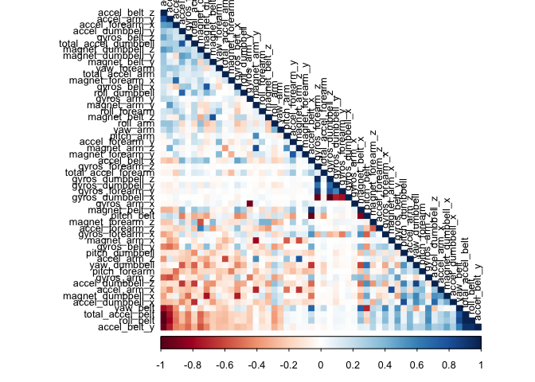

```r
training_outcome <- trainData[,-53]
correlation_Mat <- cor(training_outcome)
corrplot(correlation_Mat, order = "FPC", method = "color", type = "lower",
         tl.cex = 0.8, tl.col = rgb(0, 0, 0))
```

## Prediction Models

Now we want to build the model. There are different methods to do this, and here we will use 3 different methods and evaluate their accuracy. In the end we will see which is the most accurate. The three methods we will use are random forest, decision tree and boosting.

### Random Forest

```r
# Here we will use the cross validation method in the training control
controlRF <- trainControl(method="cv", number=3, verboseIter=FALSE)
# Build model
modelFitRF <- train(classe~. , data = trainData, method = "rf", trControl = controlRF)
modelFitRF
```

```
## Random Forest
##
## 13737 samples
##    52 predictor
##     5 classes: 'A', 'B', 'C', 'D', 'E'
##
## No pre-processing
## Resampling: Cross-Validated (3 fold)
## Summary of sample sizes: 9157, 9158, 9159
## Resampling results across tuning parameters:
##
##   mtry  Accuracy   Kappa
##    2    0.9871880  0.9837922
##   27    0.9880616  0.9848977
##   52    0.9799081  0.9745802
##
## Accuracy was used to select the optimal model using the largest value.
## The final value used for the model was mtry = 27.
```

Now we will use the model on the testing data:

```r
predRF <- predict(modelFitRF, testData)
cmRF <- confusionMatrix(factor(testData$classe), predRF)
cmRF
```

```
## Confusion Matrix and Statistics
##
##           Reference
## Prediction    A    B    C    D    E
##          A 1673    1    0    0    0
##          B    2 1135    2    0    0
##          C    0   15 1000   11    0
##          D    0    0    9  954    1
##          E    0    0    1    4 1077
##
## Overall Statistics
##
##                Accuracy : 0.9922
##                  95% CI : (0.9896, 0.9943)
##     No Information Rate : 0.2846
##     P-Value [Acc > NIR] : < 2.2e-16
##
##                   Kappa : 0.9901
##
##  Mcnemar's Test P-Value : NA
##
## Statistics by Class:
##
##                      Class: A Class: B Class: C Class: D Class: E
## Sensitivity            0.9988   0.9861   0.9881   0.9845   0.9991
## Specificity            0.9998   0.9992   0.9947   0.9980   0.9990
## Pos Pred Value         0.9994   0.9965   0.9747   0.9896   0.9954
## Neg Pred Value         0.9995   0.9966   0.9975   0.9970   0.9998
## Prevalence             0.2846   0.1956   0.1720   0.1647   0.1832
## Detection Rate         0.2843   0.1929   0.1699   0.1621   0.1830
## Detection Prevalence   0.2845   0.1935   0.1743   0.1638   0.1839
## Balanced Accuracy      0.9993   0.9926   0.9914   0.9912   0.9990
```

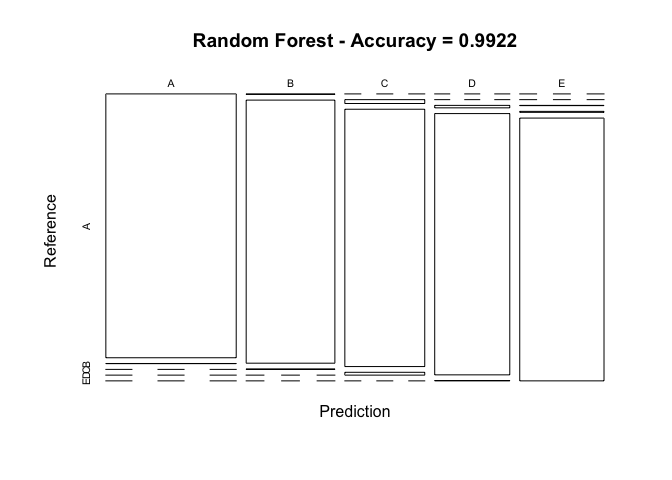

```r
# plot matrix
plot(cmRF$table, col = cmRF$byClass,
     main = paste("Random Forest - Accuracy =", round(cmRF$overall['Accuracy'], 4)))
```

### Decision Tree

```r
# Build model
modelFitDT <- rpart(classe~. , data = trainData, method = "class")
modelFitDT
```

```
## n= 13737
##
## node), split, n, loss, yval, (yprob)
##       * denotes terminal node
##
##     1) root 13737 9831 A (0.28 0.19 0.17 0.16 0.18)
##       2) roll_belt< 130.5 12618 8718 A (0.31 0.21 0.19 0.18 0.11)
##         4) pitch_forearm< -33.95 1136    7 A (0.99 0.0062 0 0 0) *
##         5) pitch_forearm>=-33.95 11482 8711 A (0.24 0.23 0.21 0.2 0.12)
##          10) magnet_dumbbell_y< 439.5 9715 7001 A (0.28 0.18 0.24 0.19 0.11)
##            20) roll_forearm< 122.5 6037 3589 A (0.41 0.18 0.18 0.17 0.063)
##              40) magnet_dumbbell_z< -27.5 2028  675 A (0.67 0.22 0.011 0.075 0.03)
##                80) roll_forearm>=-136.5 1682  366 A (0.78 0.18 0.013 0.021 0.0048) *
##                81) roll_forearm< -136.5 346  207 B (0.11 0.4 0 0.34 0.15) *
##              41) magnet_dumbbell_z>=-27.5 4009 2914 A (0.27 0.16 0.27 0.21 0.08)
##                82) yaw_belt>=169.5 477   57 A (0.88 0.057 0 0.061 0.0021) *
##                83) yaw_belt< 169.5 3532 2453 C (0.19 0.18 0.31 0.23 0.09)
##                 166) accel_dumbbell_y>=-40.5 3063 2251 D (0.22 0.2 0.22 0.27 0.098)
##                   332) pitch_belt< -42.95 360   71 B (0.022 0.8 0.11 0.039 0.028) *
##                   333) pitch_belt>=-42.95 2703 1905 D (0.25 0.12 0.23 0.3 0.11)
##                     666) roll_belt>=125.5 651  273 C (0.37 0.029 0.58 0.012 0.0031)
##                      1332) magnet_belt_z< -323.5 215    8 A (0.96 0 0.028 0 0.0093) *
##                      1333) magnet_belt_z>=-323.5 436   64 C (0.085 0.044 0.85 0.018 0) *
##                     667) roll_belt< 125.5 2052 1262 D (0.2 0.15 0.12 0.38 0.14)
##                      1334) pitch_belt>=1.035 1326 1013 A (0.24 0.21 0.14 0.22 0.19)
##                        2668) accel_dumbbell_z< 27.5 840  549 A (0.35 0.13 0.21 0.27 0.037)
##                          5336) yaw_forearm>=-94.65 601  310 A (0.48 0.17 0.22 0.083 0.037)
##                           10672) magnet_forearm_z>=-119.5 393  108 A (0.73 0.13 0.01 0.099 0.033) *
##                           10673) magnet_forearm_z< -119.5 208   78 C (0.029 0.25 0.62 0.053 0.043) *
##                          5337) yaw_forearm< -94.65 239   59 D (0 0.033 0.18 0.75 0.038) *
##                        2669) accel_dumbbell_z>=27.5 486  259 E (0.045 0.34 0.01 0.13 0.47)
##                          5338) roll_dumbbell< 38.61985 166   38 B (0.042 0.77 0.03 0.042 0.11) *
##                          5339) roll_dumbbell>=38.61985 320  112 E (0.047 0.12 0 0.18 0.65) *
##                      1335) pitch_belt< 1.035 726  231 D (0.15 0.033 0.098 0.68 0.041)
##                        2670) yaw_arm< -101.05 100    0 A (1 0 0 0 0) *
##                        2671) yaw_arm>=-101.05 626  131 D (0.0096 0.038 0.11 0.79 0.048) *
##                 167) accel_dumbbell_y< -40.5 469   59 C (0.0085 0.049 0.87 0.028 0.041) *
##            21) roll_forearm>=122.5 3678 2451 C (0.072 0.18 0.33 0.23 0.19)
##              42) magnet_dumbbell_y< 291.5 2146 1093 C (0.085 0.14 0.49 0.15 0.14)
##                84) magnet_forearm_z< -251 157   34 A (0.78 0.089 0 0.038 0.089) *
##                85) magnet_forearm_z>=-251 1989  936 C (0.03 0.14 0.53 0.16 0.14)
##                 170) pitch_belt>=26.15 129   25 B (0.1 0.81 0.016 0 0.078) *
##                 171) pitch_belt< 26.15 1860  809 C (0.025 0.094 0.57 0.17 0.15) *
##              43) magnet_dumbbell_y>=291.5 1532 1006 D (0.055 0.23 0.11 0.34 0.25)
##                86) accel_forearm_x>=-90.5 949  609 E (0.047 0.3 0.15 0.14 0.36)
##                 172) magnet_arm_y>=188.5 380  172 B (0.016 0.55 0.24 0.082 0.12) *
##                 173) magnet_arm_y< 188.5 569  274 E (0.069 0.14 0.1 0.17 0.52) *
##                87) accel_forearm_x< -90.5 583  187 D (0.067 0.12 0.046 0.68 0.084) *
##          11) magnet_dumbbell_y>=439.5 1767  867 B (0.032 0.51 0.038 0.23 0.19)
##            22) total_accel_dumbbell>=5.5 1275  450 B (0.045 0.65 0.053 0.027 0.23)
##              44) roll_belt>=-0.58 1076  251 B (0.053 0.77 0.063 0.032 0.086) *
##              45) roll_belt< -0.58 199    0 E (0 0 0 0 1) *
##            23) total_accel_dumbbell< 5.5 492  124 D (0 0.15 0 0.75 0.1) *
##       3) roll_belt>=130.5 1119    6 E (0.0054 0 0 0 0.99) *
```

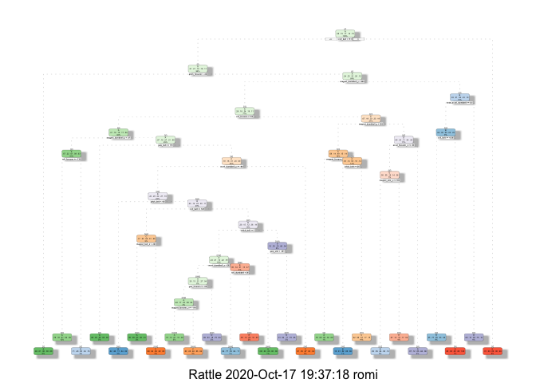

```r
# Plot decision tree
fancyRpartPlot(modelFitDT)
```

Now we will use the model on the testing data:

```r
predDT <- predict(modelFitDT, testData, type = "class")
cmDT <- confusionMatrix(factor(testData$classe), predDT)
cmDT
```

```
## Confusion Matrix and Statistics
##
##           Reference
## Prediction    A    B    C    D    E
##          A 1515   57   49   21   32
##          B  144  751  106   85   53
##          C   16   98  821   61   30
##          D   54   75  157  622   56
##          E   23   93  139   55  772
##
## Overall Statistics
##
##                Accuracy : 0.7614
##                  95% CI : (0.7503, 0.7723)
##     No Information Rate : 0.2977
##     P-Value [Acc > NIR] : < 2.2e-16
##
##                   Kappa : 0.6978
##
##  Mcnemar's Test P-Value : < 2.2e-16
##
## Statistics by Class:
##
##                      Class: A Class: B Class: C Class: D Class: E
## Sensitivity            0.8647   0.6993   0.6454   0.7370   0.8187
## Specificity            0.9615   0.9194   0.9556   0.9322   0.9373
## Pos Pred Value         0.9050   0.6594   0.8002   0.6452   0.7135
## Neg Pred Value         0.9437   0.9319   0.9072   0.9549   0.9644
## Prevalence             0.2977   0.1825   0.2161   0.1434   0.1602
## Detection Rate         0.2574   0.1276   0.1395   0.1057   0.1312
## Detection Prevalence   0.2845   0.1935   0.1743   0.1638   0.1839
## Balanced Accuracy      0.9131   0.8093   0.8005   0.8346   0.8780
```

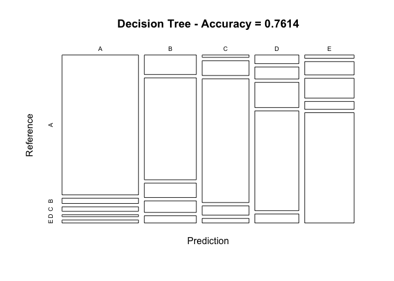

```r
# plot matrix
plot(cmDT$table, col = cmDT$byClass,
     main = paste("Decision Tree - Accuracy =", round(cmDT$overall['Accuracy'], 4)))
```

### Boosting

```r
# Here we will use the repeated cross validation method for the training control
controlGBM <- trainControl(method = "repeatedcv", number = 5, repeats = 1, verboseIter = FALSE)
#Build model
modelFitGBM <- train(classe~. , data = trainData, method = "gbm", trControl = controlGBM)
modelFitGBM
```

```
## Stochastic Gradient Boosting
##
## 13737 samples
##    52 predictor
##     5 classes: 'A', 'B', 'C', 'D', 'E'
##
## No pre-processing
## Resampling: Cross-Validated (5 fold, repeated 1 times)
## Summary of sample sizes: 10988, 10990, 10990, 10989, 10991
## Resampling results across tuning parameters:
##
##   interaction.depth  n.trees  Accuracy   Kappa
##   1                   50      0.7531505  0.6869908
##   1                  100      0.8209222  0.7733206
##   1                  150      0.8517142  0.8123303
##   2                   50      0.8552101  0.8165256
##   2                  100      0.9063114  0.8814397
##   2                  150      0.9302608  0.9117456
##   3                   50      0.8980125  0.8709083
##   3                  100      0.9427824  0.9276050
##   3                  150      0.9608355  0.9504491
##
## Tuning parameter 'shrinkage' was held constant at a value of 0.1
##
## Tuning parameter 'n.minobsinnode' was held constant at a value of 10
## Accuracy was used to select the optimal model using the largest value.
## The final values used for the model were n.trees = 150, interaction.depth =
##  3, shrinkage = 0.1 and n.minobsinnode = 10.
```

Now we will use the model on the testing data:

```r
predGBM <- predict(modelFitGBM, testData)
cmGBM <- confusionMatrix(factor(testData$classe), predGBM)
cmGBM
```

```
## Confusion Matrix and Statistics
##
##           Reference
## Prediction    A    B    C    D    E
##          A 1649   14    8    3    0
##          B   35 1075   26    1    2
##          C    0   40  972   13    1
##          D    0    3   37  917    7
##          E    1    8    7   14 1052
##
## Overall Statistics
##
##                Accuracy : 0.9626
##                  95% CI : (0.9575, 0.9673)
##     No Information Rate : 0.2863
##     P-Value [Acc > NIR] : < 2.2e-16
##
##                   Kappa : 0.9527
##
##  Mcnemar's Test P-Value : 9.752e-07
##
## Statistics by Class:
##
##                      Class: A Class: B Class: C Class: D Class: E
## Sensitivity            0.9786   0.9430   0.9257   0.9673   0.9906
## Specificity            0.9940   0.9865   0.9888   0.9905   0.9938
## Pos Pred Value         0.9851   0.9438   0.9474   0.9512   0.9723
## Neg Pred Value         0.9915   0.9863   0.9839   0.9937   0.9979
## Prevalence             0.2863   0.1937   0.1784   0.1611   0.1805
## Detection Rate         0.2802   0.1827   0.1652   0.1558   0.1788
## Detection Prevalence   0.2845   0.1935   0.1743   0.1638   0.1839
## Balanced Accuracy      0.9863   0.9647   0.9573   0.9789   0.9922
```

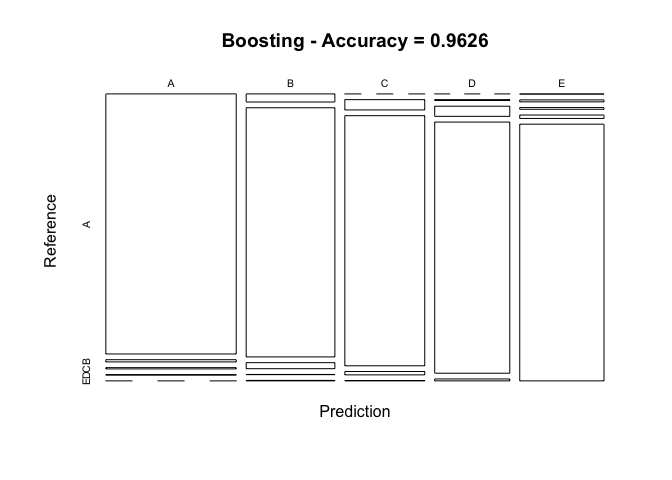

```r
# plot matrix
plot(cmGBM$table, col = cmGBM$byClass,
     main = paste("Boosting - Accuracy =", round(cmGBM$overall['Accuracy'], 4)))
```

# Apply models to testing set

We will take the model that got the highest accuracy: Random Forest. Apply on the testing set:

```r
predTEST <- predict(modelFitRF, testing)
predTEST
```

```
##  [1] B A B A A E D B A A B C B A E E A B B B
## Levels: A B C D E
```